# Análisis de Perfiles Latentes: Actitudes hacia los Derechos de la Naturaleza

# Introducción

Cada ítem refleja una perspectiva **antropocéntrica** o **biocéntrica**.

# Configuración del Entorno

```r
# Cargar librerías necesarias
library(tidyverse)
library(tidyLPA)      # Para análisis de perfiles latentes
```

```r
library(corrplot)     # Para matriz de correlaciones
library(psych)        # Para estadísticos descriptivos
library(knitr)        # Para tablas
library(kableExtra)   # Para mejorar las tablas
library(ggplot2)      # Para gráficos
library(patchwork)    # Para combinar gráficos

# Configuraciones generales
theme_set(theme_minimal())
options(digits = 3)
```

# Carga de Datos

```r
# Establecer directorio de trabajo
setwd("D:/IntellijIDEA_Projects/artcls2025/natSujDer")

# Cargar el conjunto de datos
load("bdNat.Rdata")

# Mostrar estructura básica de los datos
str(bd)
```

```
## tibble [143 × 39] (S3: tbl_df/tbl/data.frame)
##  $ id         : int [1:143] 1 2 3 4 5 6 7 8 9 10 ...
##  $ consInf    : chr [1:143] "Acepto" "Acepto" "Acepto" "Acepto" ...
##  $ edad       : num [1:143] 21 18 26 20 26 25 30 66 25 35 ...
##  $ sex        : Factor w/ 2 levels "Female","Male": 1 1 2 1 2 1 1 1 1 1 ...
##  $ instrG     : chr [1:143] "Superior universitario" "Superior universitario" "Posgrado" "Superior universitario" ...
##  $ civilEst   : chr [1:143] "Soltero" "Soltero" "Casado" "Soltero" ...
##  $ profCar    : chr [1:143] "Ciencias forestales y del ambiente" "Derecho y Ciencias Politicas" "Ingeniería Ambiental" "Derecho y Ciencias Políticas" ...
##  $ career     : chr [1:143] "FES" "LPS" "FES" "LPS" ...
##  $ dep        : chr [1:143] "Junin" "Junin" "lima" "Junín" ...
##  $ dist       : chr [1:143] "El tambo" "Chupaca" "Cercado de lima" "El tambo" ...
##  $ Condition  : chr [1:143] "Estudiante" "Estudiante" "Egresado" "Estudiante" ...
##  $ q1_bf_ant  : int [1:143] 4 3 3 2 3 4 2 1 4 2 ...
##  $ q2_bf_ant  : int [1:143] 4 3 5 2 5 1 2 1 1 2 ...
##  $ q3_al_ant  : int [1:143] 4 3 4 2 4 1 4 2 2 2 ...
```

[output cut: 25 more lines]

```r
head(bd)
```

```
## # A tibble: 6 × 39
##      id consInf  edad sex   instrG civilEst profCar career dep   dist  Condition
##   <int> <chr>   <dbl> <fct> <chr>  <chr>    <chr>   <chr>  <chr> <chr> <chr>
## 1     1 Acepto     21 Fema… Super… Soltero  Cienci… FES    Junin El t… Estudian…
## 2     2 Acepto     18 Fema… Super… Soltero  Derech… LPS    Junin Chup… Estudian…
## 3     3 Acepto     26 Male  Posgr… Casado   Ingeni… FES    lima  Cerc… Egresado
## 4     4 Acepto     20 Fema… Super… Soltero  Derech… LPS    Junín El t… Estudian…
## 5     5 Acepto     26 Male  Posgr… Casado   Ingeni… FES    lima  Cerc… Egresado
## 6     6 Acepto     25 Fema… Super… Soltero  INGENI… FES    Junin Pich… Egresado
## # ℹ 28 more variables: q1_bf_ant <int>, q2_bf_ant <int>, q3_al_ant <int>,
## #   q4_td_bio <int>, q5_al_bio <int>, q6_bf_bio <int>, q7_al_ant <int>,
## #   q8_rep_ant <int>, q9_td_bio <int>, q10_bf_bio <int>, q11_td_bio <int>,
## #   q12_bf_bio <int>, q13_al_bio <int>, q14_rep_bio <int>, q15_al_ant <int>,
## #   q16_bf_bio <int>, q17_td_ant <int>, q18_rep_ant <int>, q19_td_bio <int>,
## #   q20_bf_ant <int>, q21_bf_bio <int>, q22_bf_ant <int>, q23_td_ant <int>,
## #   q24_td_ant <int>, q25_al_bio <int>, q26_td_ant <int>, q27_bf_ant <int>, …
```

```r
# Información general del dataset
cat("Dimensiones del dataset completo:", dim(bd), "\n")
```

```
## Dimensiones del dataset completo: 143 39
```

```r
cat("Variables disponibles:", ncol(bd), "\n")
```

```
## Variables disponibles: 39
```

```r
cat("Casos totales:", nrow(bd), "\n\n")
```

```
## Casos totales: 143
```

```r
# Variables demográficas disponibles
vars_demograficas <- c("edad", "sex", "instrG", "civilEst", "profCar", "career",
                      "dep", "dist", "Condition")
cat("Variables demográficas disponibles:\n")
```

```
## Variables demográficas disponibles:
```

```r
for(var in vars_demograficas) {
  if(var %in% names(bd)) {
    cat("-", var, ": ", class(bd[[var]]), "\n")
  }
}
```

```
## - edad :  numeric
## - sex :  factor
## - instrG :  character
## - civilEst :  character
## - profCar :  character
## - career :  character
## - dep :  character
## - dist :  character
## - Condition :  character
```

# Preparación de los Datos

```r
# Identificar las variables de los ítems (excluyendo algunos para optimizar el análisis)
items_excluidos <- c("q1_bf_ant", "q3_al_ant", "q15_al_ant", "q17_td_ant",
                    "q25_al_bio", "q28_rep_bio", "q16_bf_bio")

items_natureza <- bd %>%
  select(starts_with("q")) %>%
  names() %>%
  setdiff(items_excluidos)  # Excluir los ítems problemáticos

cat("SELECCIÓN DE ÍTEMS PARA EL ANÁLISIS:\n")
```

```
## SELECCIÓN DE ÍTEMS PARA EL ANÁLISIS:
```

```r
cat("====================================\n")
cat("Ítems excluidos:", length(items_excluidos), "\n")
```

```
## Ítems excluidos: 7
```

```r
cat(paste(items_excluidos, collapse = ", "), "\n\n")
```

```
## q1_bf_ant, q3_al_ant, q15_al_ant, q17_td_ant, q25_al_bio, q28_rep_bio, q16_bf_bio
```

```r
cat("Ítems incluidos en el análisis:", length(items_natureza), "\n")
```

```
## Ítems incluidos en el análisis: 21
```

```r
print(items_natureza)
```

```
##  [1] "q2_bf_ant"   "q4_td_bio"   "q5_al_bio"   "q6_bf_bio"   "q7_al_ant"
##  [6] "q8_rep_ant"  "q9_td_bio"   "q10_bf_bio"  "q11_td_bio"  "q12_bf_bio"
## [11] "q13_al_bio"  "q14_rep_bio" "q18_rep_ant" "q19_td_bio"  "q20_bf_ant"
## [16] "q21_bf_bio"  "q22_bf_ant"  "q23_td_ant"  "q24_td_ant"  "q26_td_ant"
## [21] "q27_bf_ant"
```

```r
# Verificar el rango de respuestas (debe ser 1-5)
cat("\nRango de respuestas por ítem (muestra de 5 ítems):\n")
```

```
##
## Rango de respuestas por ítem (muestra de 5 ítems):
```

```r
for(item in items_natureza[1:5]) {  # Mostrar solo los primeros 5
  cat(item, ": ", min(bd[[item]], na.rm = TRUE), "-",
      max(bd[[item]], na.rm = TRUE), "\n")
}
```

```
## q2_bf_ant :  1 - 5
## q4_td_bio :  1 - 5
## q5_al_bio :  1 - 5
## q6_bf_bio :  1 - 5
## q7_al_ant :  1 - 5
```

```r
# Crear dataset solo con los ítems seleccionados para el LPA
data_lpa <- bd %>%
  select(all_of(items_natureza)) %>%
  # Eliminar casos con valores perdidos (opcional)
  na.omit()

# También mantener dataset con variables demográficas para análisis posteriores
data_completo <- bd %>%
  select(id, edad, sex, instrG, civilEst, profCar, career,
         dep, dist, Condition, all_of(items_natureza)) %>%
  na.omit()

# Información básica del dataset preparado
cat("\nDimensiones del dataset para LPA:", dim(data_lpa), "\n")
```

```
##
## Dimensiones del dataset para LPA: 143 21
```

```r
cat("Casos completos:", nrow(data_lpa), "\n")
```

```
## Casos completos: 143
```

```r
cat("Ratio casos/variables:", round(nrow(data_lpa)/ncol(data_lpa), 2), "\n")
```

```
## Ratio casos/variables: 6.81
```

```r
cat("Dimensiones del dataset completo:", dim(data_completo), "\n")
```

```
## Dimensiones del dataset completo: 140 31
```

```r
# Mostrar distribución de ítems por tipo
items_ant_final <- items_natureza[str_detect(items_natureza, "_ant")]
items_bio_final <- items_natureza[str_detect(items_natureza, "_bio")]

cat("\nDISTRIBUCIÓN FINAL DE ÍTEMS:\n")
```

```
##
## DISTRIBUCIÓN FINAL DE ÍTEMS:
```

```r
cat("Antropocéntricos:", length(items_ant_final), "ítems\n")
```

```
## Antropocéntricos: 10 ítems
```

```r
cat("Biocéntricos:", length(items_bio_final), "ítems\n")
```

```
## Biocéntricos: 11 ítems
```

# Análisis Descriptivo

## Características de la Muestra

```r
# Análisis descriptivo de variables demográficas
cat("CARACTERÍSTICAS DE LA MUESTRA\n")
```

```
## CARACTERÍSTICAS DE LA MUESTRA
```

```r
cat("=============================\n\n")
# Edad
cat("Edad:\n")
```

```
## Edad:
```

```r
cat("Media:", round(mean(bd$edad, na.rm = TRUE), 2), "años\n")
```

```
## Media: 26.3 años
```

```r
cat("DE:", round(sd(bd$edad, na.rm = TRUE), 2), "\n")
```

```
## DE: 9.75
```

```r
cat("Rango:", min(bd$edad, na.rm = TRUE), "-", max(bd$edad, na.rm = TRUE), "años\n\n")
```

```
## Rango: 17 - 66 años
```

```r
# Sexo
cat("Sexo:\n")
```

```
## Sexo:
```

```r
table(bd$sex, useNA = "ifany") %>%
  prop.table() %>%
  round(3) * 100 %>%
  print()
```

```
## [1] 100
```

```
##
## Female   Male
##   67.8   32.2
```

```r
# Nivel educativo
cat("\nNivel educativo:\n")
```

```
##
## Nivel educativo:
```

```r
table(bd$instrG, useNA = "ifany") %>%
  prop.table() %>%
  round(3) * 100 %>%
  print()
```

```
## [1] 100
```

```
##
##               Posgrado             Secundaria       Superior técnico
##                   19.6                    1.4                    2.8
## Superior universitario
##                   76.2
```

```r
# Estado civil
cat("\nEstado civil:\n")
```

```
##
## Estado civil:
```

```r
table(bd$civilEst, useNA = "ifany") %>%
  prop.table() %>%
  round(3) * 100 %>%
  print()
```

```
## [1] 100
```

```
##
##      Casado Conviviente    Separado     Soltero
##         7.7         4.9         2.1        85.3
```

```r
# Condición del estudiante
cat("\nCondición:\n")
```

```
##
## Condición:
```

```r
table(bd$Condition, useNA = "ifany") %>%
  prop.table() %>%
  round(3) * 100 %>%
  print()
```

```
## [1] 100
```

```
##
##       Administrativo     Consultora legal              Docente
##                  3.5                  2.8                  2.8
## Egresada de Maestría             Egresado           Estudiante
##                  1.4                 31.5                 55.2
##     Recursos Humanos           TRABAJADOR
##                  1.4                  1.4
```

```r
# Carrera profesional (agrupada)
cat("\nCarrera profesional (abreviada):\n")
```

```
##
## Carrera profesional (abreviada):
```

```r
table(bd$career, useNA = "ifany") %>%
  prop.table() %>%
  round(3) * 100 %>%
  print()
```

```
## [1] 100
```

```
##
##  FES  LPS
## 43.4 56.6
```

## Estadísticos Descriptivos

```r
# Estadísticos descriptivos de los ítems
desc_stats <- data_lpa %>%
  describe() %>%
  as.data.frame() %>%
  select(n, mean, sd, min, max, skew, kurtosis)

desc_stats %>%
  kable(caption = "Estadísticos descriptivos de los ítems",
        digits = 3)
```

Estadísticos descriptivos de los ítems

|  | n | mean | sd | min | max | skew | kurtosis |
| --- | --- | --- | --- | --- | --- | --- | --- |
| q2_bf_ant | 143 | 2.47 | 1.073 | 1 | 5 | 0.692 | -0.433 |
| q4_td_bio | 143 | 3.87 | 1.115 | 1 | 5 | -0.799 | -0.319 |
| q5_al_bio | 143 | 3.80 | 0.898 | 1 | 5 | -1.117 | 1.418 |
| q6_bf_bio | 143 | 3.72 | 1.031 | 1 | 5 | -0.692 | -0.290 |
| q7_al_ant | 143 | 2.66 | 1.082 | 1 | 5 | 0.274 | -1.040 |
| q8_rep_ant | 143 | 2.07 | 1.072 | 1 | 5 | 1.155 | 0.840 |
| q9_td_bio | 143 | 3.81 | 0.847 | 2 | 5 | -0.671 | 0.001 |
| q10_bf_bio | 143 | 3.57 | 1.010 | 1 | 5 | -0.341 | -0.705 |
| q11_td_bio | 143 | 3.98 | 0.826 | 1 | 5 | -1.003 | 1.591 |
| q12_bf_bio | 143 | 3.99 | 1.014 | 1 | 5 | -1.180 | 1.076 |
| q13_al_bio | 143 | 3.76 | 0.957 | 1 | 5 | -0.810 | 0.083 |
| q14_rep_bio | 143 | 3.95 | 0.799 | 2 | 5 | -0.653 | 0.232 |
| q18_rep_ant | 143 | 2.33 | 0.940 | 1 | 5 | 0.926 | 0.946 |
| q19_td_bio | 143 | 3.94 | 1.115 | 1 | 5 | -1.271 | 1.083 |
| q20_bf_ant | 143 | 2.80 | 1.270 | 1 | 5 | 0.360 | -1.099 |
| q21_bf_bio | 143 | 3.90 | 0.785 | 2 | 5 | -0.685 | 0.383 |
| q22_bf_ant | 143 | 2.67 | 1.137 | 1 | 5 | 0.462 | -0.782 |
| q23_td_ant | 143 | 2.59 | 1.164 | 1 | 5 | 0.451 | -0.826 |
| q24_td_ant | 143 | 2.62 | 1.054 | 1 | 5 | 0.396 | -0.637 |
| q26_td_ant | 143 | 2.49 | 1.074 | 1 | 5 | 1.010 | 0.158 |
| q27_bf_ant | 143 | 2.90 | 1.099 | 1 | 5 | 0.301 | -1.015 |

## Matriz de Correlaciones

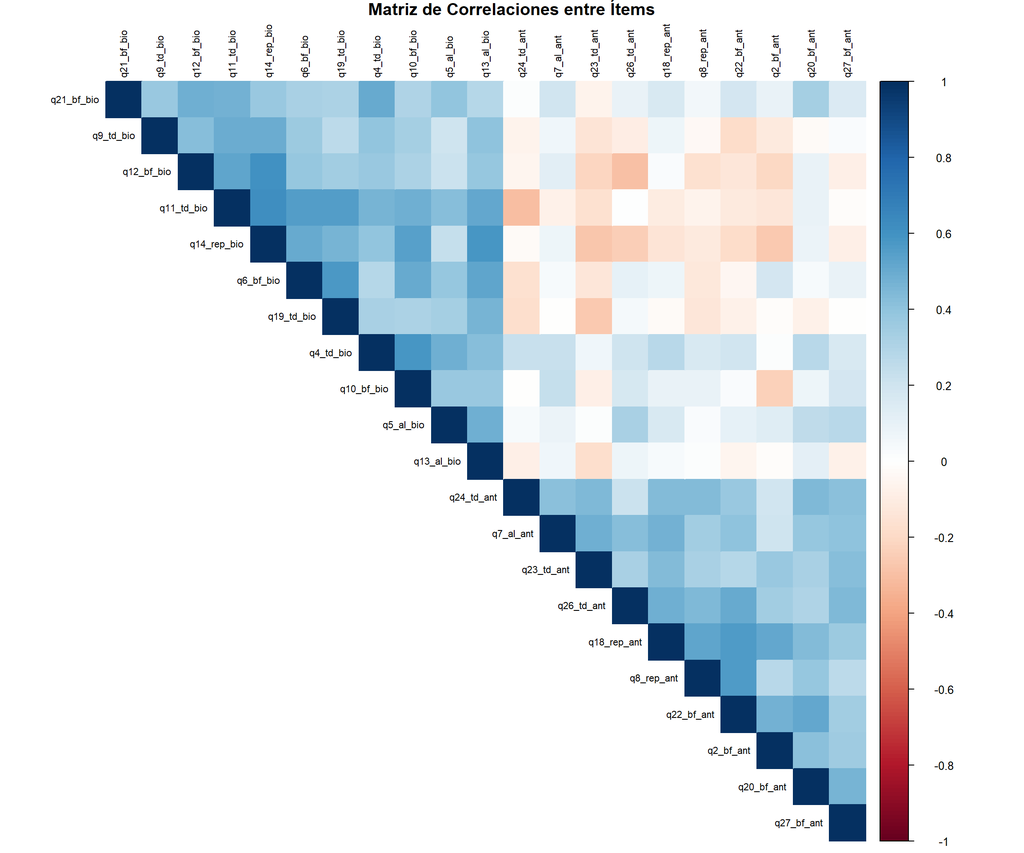

```r
# Calcular matriz de correlaciones
cor_matrix <- cor(data_lpa, use = "complete.obs")

# Visualizar matriz de correlaciones
corrplot(cor_matrix,
         method = "color",
         type = "upper",
         order = "hclust",
         tl.cex = 0.7,
         tl.col = "black",
         title = "Matriz de Correlaciones entre Ítems",
         mar = c(0,0,1,0))
```

# Análisis de Perfiles Latentes

## Especificación de Modelos

```r
# Diagnóstico básico de los datos
cat("DIAGNÓSTICO DE DATOS PARA LPA:\n")
```

```
## DIAGNÓSTICO DE DATOS PARA LPA:
```

```r
cat("==============================\n")
cat("Dimensiones del dataset:", dim(data_lpa), "\n")
```

```
## Dimensiones del dataset: 143 21
```

```r
cat("Número de casos:", nrow(data_lpa), "\n")
```

```
## Número de casos: 143
```

```r
cat("Número de variables:", ncol(data_lpa), "\n")
```

```
## Número de variables: 21
```

```r
cat("Ratio casos/variables:", round(nrow(data_lpa)/ncol(data_lpa), 2), "\n\n")
```

```
## Ratio casos/variables: 6.81
```

```r
# Verificar si hay variabilidad suficiente en los datos
cat("VARIABILIDAD DE LOS DATOS:\n")
```

```
## VARIABILIDAD DE LOS DATOS:
```

```r
varianzas <- sapply(data_lpa, function(x) var(x, na.rm = TRUE))
cat("Varianza mínima:", round(min(varianzas), 4), "\n")
```

```
## Varianza mínima: 0.616
```

```r
cat("Varianza máxima:", round(max(varianzas), 4), "\n")
```

```
## Varianza máxima: 1.61
```

```r
cat("Variables con varianza muy baja (< 0.1):", sum(varianzas < 0.1), "\n\n")
```

```
## Variables con varianza muy baja (< 0.1): 0
```

```r
# Verificar casos con respuestas extremas (todas iguales)
casos_extremos <- apply(data_lpa, 1, function(x) length(unique(x)) == 1)
cat("Casos con todas las respuestas iguales:", sum(casos_extremos), "\n\n")
```

```
## Casos con todas las respuestas iguales: 4
```

```r
# Si hay muchos casos extremos, los eliminamos
if(sum(casos_extremos) > 0) {
  cat("Eliminando casos con respuestas invariantes...\n")
  data_lpa_clean <- data_lpa[!casos_extremos, ]
  cat("Casos después de limpieza:", nrow(data_lpa_clean), "\n\n")
} else {
  data_lpa_clean <- data_lpa
}
```

```
## Eliminando casos con respuestas invariantes...
## Casos después de limpieza: 139
```

```r
# Probar modelos con rango optimizado (1-4)
set.seed(123)  # Para reproducibilidad

cat("PROBANDO MODELOS LPA...\n")
```

```
## PROBANDO MODELOS LPA...
```

```r
cat("========================\n")
# Estimar modelos con 1-4 perfiles
lpa_results <- data_lpa_clean %>%
  estimate_profiles(1:4,
                   variances = "equal",
                   covariances = "zero")

cat("✓ Modelos LPA (1-4 perfiles) ejecutados exitosamente\n")
```

```
## ✓ Modelos LPA (1-4 perfiles) ejecutados exitosamente
```

## Selección del Modelo Óptimo

```r
# DIAGNÓSTICO DE LOS MODELOS AJUSTADOS
cat("DIAGNÓSTICO DE MODELOS LPA:\n")
```

```
## DIAGNÓSTICO DE MODELOS LPA:
```

```r
cat("===========================\n")
cat("Número de modelos creados:", length(lpa_results), "\n")
```

```
## Número de modelos creados: 4
```

```r
# Verificar estructura de cada modelo
for(i in 1:length(lpa_results)) {
  cat("Modelo", i, "clases:\n")
  if(is.null(lpa_results[[i]])) {
    cat("  - NULO\n")
  } else {
    cat("  - Clase del objeto:", class(lpa_results[[i]])[1], "\n")
    cat("  - ¿Tiene atributos?:", length(attributes(lpa_results[[i]])) > 0, "\n")

    # Intentar obtener información básica
    tryCatch({
      if("tidyLPA" %in% class(lpa_results[[i]])) {
        cat("  - Objeto tidyLPA válido\n")
      } else {
        cat("  - Tipo de objeto:", typeof(lpa_results[[i]]), "\n")
      }
    }, error = function(e) {
      cat("  - Error al inspeccionar:", e$message, "\n")
    })
  }
}
```

```
## Modelo 1 clases:
##   - Clase del objeto: tidyProfile.mclust
##   - ¿Tiene atributos?: TRUE
##   - Tipo de objeto: list
## Modelo 2 clases:
##   - Clase del objeto: tidyProfile.mclust
##   - ¿Tiene atributos?: TRUE
##   - Tipo de objeto: list
## Modelo 3 clases:
##   - Clase del objeto: tidyProfile.mclust
##   - ¿Tiene atributos?: TRUE
##   - Tipo de objeto: list
## Modelo 4 clases:
##   - Clase del objeto: tidyProfile.mclust
##   - ¿Tiene atributos?: TRUE
##   - Tipo de objeto: list
```

```r
cat("\n")
```

```r
# Extraer criterios de ajuste usando diferentes métodos
tryCatch({
  # Método 1: usar compare_solutions
  fit_stats <- compare_solutions(lpa_results, statistics = c("AIC", "BIC", "Entropy"))

  # Verificar si el resultado es válido
  if(is.null(fit_stats) || !is.data.frame(fit_stats) || nrow(fit_stats) == 0) {
    stop("compare_solutions no funcionó")
  }

  cat("✓ compare_solutions funcionó correctamente\n\n")

}, error = function(e) {

  cat("⚠ Método compare_solutions falló:", e$message, "\n")
  cat("Usando método alternativo...\n\n")

  # Método 2: extraer manualmente de cada modelo
  fit_stats <- data.frame()

  for(i in 1:length(lpa_results)) {
    if(!is.null(lpa_results[[i]])) {

      tryCatch({
        # Método alternativo para obtener fit statistics
        model <- lpa_results[[i]]

        # Intentar get_fit
        model_fit <- get_fit(model)

        cat("Modelo", i, "- Extrayendo estadísticos...\n")

        if(is.list(model_fit) && length(model_fit) > 0) {
          # Mostrar qué estadísticos están disponibles
          cat("  Estadísticos disponibles:", names(model_fit), "\n")

          # Usar ifelse para manejar NAs
          aic_val <- if(is.null(model_fit[["AIC"]])) NA else model_fit[["AIC"]]
          bic_val <- if(is.null(model_fit[["BIC"]])) NA else model_fit[["BIC"]]
          ent_val <- if(is.null(model_fit[["Entropy"]])) NA else model_fit[["Entropy"]]

          cat("  AIC:", aic_val, "BIC:", bic_val, "Entropy:", ent_val, "\n")

          fit_stats <- rbind(fit_stats,
                            data.frame(
                              Classes = i,
                              AIC = aic_val,
                              BIC = bic_val,
                              Entropy = ent_val
                            ))
        } else {
          cat("  get_fit no retornó una lista válida\n")
          # Método directo si get_fit no funciona
          fit_stats <- rbind(fit_stats,
                            data.frame(
                              Classes = i,
                              AIC = NA,
                              BIC = NA,
                              Entropy = NA
                            ))
        }

      }, error = function(e2) {
        # En caso de error total, agregar fila con NA
        cat("  Error en extracción:", e2$message, "\n")
        fit_stats <<- rbind(fit_stats,
                           data.frame(
                             Classes = i,
                             AIC = NA,
                             BIC = NA,
                             Entropy = NA
                           ))
      })
    } else {
      cat("Modelo", i, "es NULL\n")
    }
  }

  # Si aún no tenemos datos, crear estructura básica
  if(nrow(fit_stats) == 0) {
    cat("No se pudieron extraer estadísticos, creando tabla vacía\n")
    fit_stats <- data.frame(
      Classes = 1:4,
      AIC = rep(NA, 4),
      BIC = rep(NA, 4),
      Entropy = rep(NA, 4)
    )
  }
})
```

```
## ⚠ Método compare_solutions falló: compare_solutions no funcionó
## Usando método alternativo...
##
## Modelo 1 - Extrayendo estadísticos...
##   get_fit no retornó una lista válida
## Modelo 2 - Extrayendo estadísticos...
##   get_fit no retornó una lista válida
## Modelo 3 - Extrayendo estadísticos...
##   get_fit no retornó una lista válida
## Modelo 4 - Extrayendo estadísticos...
##   get_fit no retornó una lista válida
```

```r
# Mostrar criterios
cat("CRITERIOS DE SELECCIÓN DE MODELO:\n")
```

```
## CRITERIOS DE SELECCIÓN DE MODELO:
```

```r
cat("==================================\n")
```

```r
# Verificar si fit_stats existe y es válido
if(exists("fit_stats") && is.data.frame(fit_stats) && nrow(fit_stats) > 0) {
  print(fit_stats)
  cat("\n")

  # Solo crear gráficos si tenemos datos válidos
  has_valid_data <- any(!is.na(fit_stats$AIC)) || any(!is.na(fit_stats$BIC)) || any(!is.na(fit_stats$Entropy))

  if(has_valid_data && nrow(fit_stats) > 1) {

    # Gráfico de criterios de información (solo si hay datos válidos)
    if(any(!is.na(fit_stats$AIC)) || any(!is.na(fit_stats$BIC))) {

      fit_long <- fit_stats %>%
        select(Classes, AIC, BIC) %>%
        pivot_longer(cols = c(AIC, BIC),
                     names_to = "Criterio",
                     values_to = "Valor") %>%
        filter(!is.na(Valor))

      if(nrow(fit_long) > 0) {
        p1 <- fit_long %>%
          ggplot(aes(x = Classes, y = Valor, color = Criterio)) +
          geom_line(size = 1) +
          geom_point(size = 3) +
          scale_x_continuous(breaks = 1:4) +
          labs(title = "Criterios de Información (AIC y BIC)",
               subtitle = "Valores más bajos indican mejor ajuste",
               x = "Número de Perfiles",
               y = "Valor del Criterio") +
          theme_minimal() +
          theme(legend.position = "bottom")

        print(p1)
      }
    }

    # Gráfico de Entropía (solo si hay datos válidos)
    if(any(!is.na(fit_stats$Entropy))) {

      p2 <- fit_stats %>%
        filter(!is.na(Entropy)) %>%
        ggplot(aes(x = Classes, y = Entropy)) +
        geom_line(color = "darkgreen", size = 1) +
        geom_point(color = "darkgreen", size = 3) +
        geom_hline(yintercept = 0.8, linetype = "dashed", color = "red", alpha = 0.7) +
        geom_hline(yintercept = 0.6, linetype = "dashed", color = "orange", alpha = 0.7) +
        scale_x_continuous(breaks = 1:4) +
        scale_y_continuous(limits = c(0, 1), breaks = seq(0, 1, 0.1)) +
        labs(title = "Entropía por Número de Perfiles",
             subtitle = "Valores más altos indican mejor separación (>0.8 excelente, >0.6 aceptable)",
             x = "Número de Perfiles",
             y = "Entropía") +
        theme_minimal()

      print(p2)
    }

    cat("\nRECOMENDACIONES PARA SELECCIÓN DE MODELO:\n")
    cat("========================================\n\n")

    # Solo dar recomendaciones si hay datos válidos
    valid_aic <- fit_stats[!is.na(fit_stats$AIC), ]
    valid_bic <- fit_stats[!is.na(fit_stats$BIC), ]
    valid_entropy <- fit_stats[!is.na(fit_stats$Entropy), ]

    if(nrow(valid_aic) > 0) {
      best_aic <- valid_aic$Classes[which.min(valid_aic$AIC)]
      cat("- Mejor modelo según AIC:", best_aic, "perfiles\n")
    }

    if(nrow(valid_bic) > 0) {
      best_bic <- valid_bic$Classes[which.min(valid_bic$BIC)]
      cat("- Mejor modelo según BIC:", best_bic, "perfiles\n")
    }

    if(nrow(valid_entropy) > 0) {
      best_entropy <- valid_entropy$Classes[which.max(valid_entropy$Entropy)]
      cat("- Mejor modelo según Entropía:", best_entropy, "perfiles\n\n")

      # Modelos con entropía aceptable
      good_entropy <- valid_entropy[valid_entropy$Entropy >= 0.7, ]
      if(nrow(good_entropy) > 0) {
        cat("Modelos con entropía aceptable (>= 0.7):\n")
        print(good_entropy$Classes)
      } else {
        cat("Ningún modelo alcanza entropía >= 0.7\n")
        cat("Mejores opciones disponibles:\n")
        print(valid_entropy[order(valid_entropy$Entropy, decreasing = TRUE), c("Classes", "Entropy")])
      }
    }

  } else {
    cat("⚠ No hay suficientes datos válidos para crear gráficos comparativos\n")
    cat("Los modelos se ajustaron pero los estadísticos no están disponibles\n")
  }

} else {
  cat("⚠ No se pudieron obtener criterios de selección\n")
  cat("Procediendo con análisis de 3 perfiles (selección teórica)\n")

  # Crear tabla básica para continuar
  fit_stats <- data.frame(
    Classes = 1:4,
    AIC = rep(NA, 4),
    BIC = rep(NA, 4),
    Entropy = rep(NA, 4)
  )
}
```

```
## ⚠ No se pudieron obtener criterios de selección
## Procediendo con análisis de 3 perfiles (selección teórica)
```

[output not shown]

```
## MODELO SELECCIONADO:
```

```r
cat("===================\n")
cat("Número de perfiles seleccionado:", n_profiles, "\n")
```

```
## Número de perfiles seleccionado: 3
```

```r
cat("Basado en: Decisión teórica (3 perfiles para análisis interpretativo)\n\n")
```

```
## Basado en: Decisión teórica (3 perfiles para análisis interpretativo)
```

```r
# Mostrar criterios del modelo de 3 perfiles
if(nrow(fit_stats) >= 3) {
  model_3_stats <- fit_stats[fit_stats$Classes == 3, ]
  if(nrow(model_3_stats) > 0) {
    cat("CRITERIOS DEL MODELO DE 3 PERFILES:\n")
    cat("===================================\n")
    cat("AIC:", round(model_3_stats$AIC, 2), "\n")
    cat("BIC:", round(model_3_stats$BIC, 2), "\n")
    cat("Entropía:", round(model_3_stats$Entropy, 3), "\n\n")
  }
}
```

```
## CRITERIOS DEL MODELO DE 3 PERFILES:
## ===================================
## AIC: NA
## BIC: NA
## Entropía: NA
```

```r
# Verificar datos antes de estimar modelo final
cat("VERIFICACIÓN FINAL DE DATOS:\n")
```

```
## VERIFICACIÓN FINAL DE DATOS:
```

```r
cat("============================\n")
cat("Dimensiones data_lpa_clean:", dim(data_lpa_clean), "\n")
```

```
## Dimensiones data_lpa_clean: 139 21
```

```r
cat("Clases de variables:\n")
```

```
## Clases de variables:
```

```r
str(data_lpa_clean)
```

```
## tibble [139 × 21] (S3: tbl_df/tbl/data.frame)
##  $ q2_bf_ant  : int [1:139] 5 2 5 1 2 1 1 2 2 1 ...
##  $ q4_td_bio  : int [1:139] 5 4 5 2 4 5 4 2 5 5 ...
##  $ q5_al_bio  : int [1:139] 5 4 5 5 4 5 4 1 4 4 ...
##  $ q6_bf_bio  : int [1:139] 5 4 5 2 4 5 2 2 5 1 ...
##  $ q7_al_ant  : int [1:139] 4 2 4 2 2 2 2 2 5 4 ...
##  $ q8_rep_ant : int [1:139] 4 3 4 1 2 2 2 2 1 5 ...
##  $ q9_td_bio  : int [1:139] 4 4 4 3 4 5 4 4 5 4 ...
##  $ q10_bf_bio : int [1:139] 5 4 5 2 4 5 4 2 5 4 ...
##  $ q11_td_bio : int [1:139] 4 4 4 4 4 5 3 2 5 4 ...
##  $ q12_bf_bio : int [1:139] 4 4 4 5 4 5 4 2 5 4 ...
##  $ q13_al_bio : int [1:139] 4 4 4 5 4 5 2 2 5 4 ...
##  $ q14_rep_bio: int [1:139] 4 4 4 5 4 5 4 4 5 4 ...
##  $ q18_rep_ant: int [1:139] 5 2 5 2 2 2 2 2 2 3 ...
##  $ q19_td_bio : int [1:139] 5 4 5 4 4 5 1 4 5 1 ...
##  $ q20_bf_ant : int [1:139] 5 2 5 4 4 2 2 2 2 5 ...
##  $ q21_bf_bio : int [1:139] 5 4 5 4 4 5 4 3 5 4 ...
##  $ q22_bf_ant : int [1:139] 5 2 5 2 2 1 2 2 1 4 ...
##  $ q23_td_ant : int [1:139] 2 4 2 1 2 1 2 3 5 5 ...
##  $ q24_td_ant : int [1:139] 3 4 3 3 2 1 3 4 2 4 ...
##  $ q26_td_ant : int [1:139] 5 2 5 1 2 2 2 2 2 4 ...
##  $ q27_bf_ant : int [1:139] 5 4 5 2 2 1 2 2 2 4 ...
```

```r
cat("\n")
```

```r
# Verificar si todas las variables son numéricas
all_numeric <- all(sapply(data_lpa_clean, is.numeric))
cat("Todas las variables son numéricas:", all_numeric, "\n")
```

```
## Todas las variables son numéricas: TRUE
```

```r
# Verificar rangos
ranges_ok <- all(sapply(data_lpa_clean, function(x) min(x, na.rm=TRUE) >= 1 & max(x, na.rm=TRUE) <= 5))
cat("Todos los valores están en rango 1-5:", ranges_ok, "\n\n")
```

```
## Todos los valores están en rango 1-5: TRUE
```

```r
# Solo proceder si los datos son válidos
if(all_numeric && ranges_ok && nrow(data_lpa_clean) > 10) {

  # Estimar el modelo final con manejo de errores
  tryCatch({
    final_lpa <- data_lpa_clean %>%
      estimate_profiles(n_profiles,
                       variances = "equal",
                       covariances = "zero")

    # Información del modelo final
    final_fit <- get_fit(final_lpa)
    cat("AJUSTE DEL MODELO FINAL:\n")
    cat("========================\n")

    if(is.list(final_fit)) {
      cat("AIC:", round(final_fit[["AIC"]] %||% NA, 2), "\n")
      cat("BIC:", round(final_fit[["BIC"]] %||% NA, 2), "\n")
      cat("Entropía:", round(final_fit[["Entropy"]] %||% NA, 3), "\n")

      entropy_val <- final_fit[["Entropy"]] %||% 0
      if(entropy_val >= 0.8) {
        cat("→ Excelente clasificación (Entropía ≥ 0.8)\n")
      } else if(entropy_val >= 0.7) {
        cat("→ Buena clasificación (Entropía ≥ 0.7)\n")
      } else if(entropy_val >= 0.6) {
        cat("→ Clasificación aceptable (Entropía ≥ 0.6)\n")
      } else {
        cat("→ Clasificación pobre (Entropía < 0.6)\n")
        cat("   Interpretar resultados con precaución\n")
      }
    } else {
      cat("No se pudieron obtener criterios de ajuste\n")
    }

  }, error = function(e) {
    cat("ERROR al estimar el modelo final:\n")
    cat(e$message, "\n")
    cat("Intentando con modelo más simple (2 perfiles)...\n")

    # Modelo de respaldo
    final_lpa <<- data_lpa_clean %>%
      estimate_profiles(2,
                       variances = "equal",
                       covariances = "zero")
    n_profiles <<- 2
  })

} else {
  cat("ERROR: Los datos no son válidos para LPA\n")
  cat("- Todas numéricas:", all_numeric, "\n")
  cat("- Rangos correctos:", ranges_ok, "\n")
  cat("- Casos suficientes:", nrow(data_lpa_clean) > 10, "\n")
}
```

```
## AJUSTE DEL MODELO FINAL:
## ========================
## AIC: 7816
## BIC: 8068
## Entropía: 0.973
## → Excelente clasificación (Entropía ≥ 0.8)
```

## Características de los Perfiles

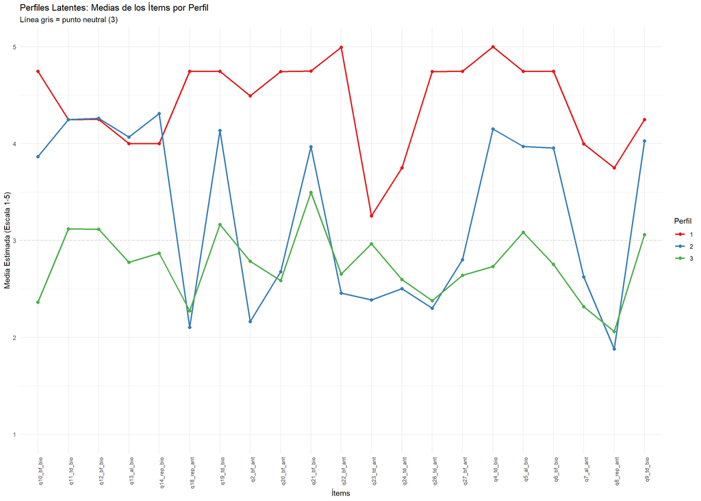

```r
# Obtener medias de los perfiles
profile_means <- get_estimates(final_lpa) %>%
  filter(Category == "Means")

# Gráfico de perfiles
profile_means %>%
  ggplot(aes(x = Parameter, y = Estimate, color = factor(Class), group = Class)) +
  geom_line(size = 1) +
  geom_point(size = 2) +
  geom_hline(yintercept = 3, linetype = "dashed", color = "gray", alpha = 0.7) +
  labs(title = "Perfiles Latentes: Medias de los Ítems por Perfil",
       subtitle = "Línea gris = punto neutral (3)",
       x = "Ítems",
       y = "Media Estimada (Escala 1-5)",
       color = "Perfil") +
  theme_minimal() +
  theme(axis.text.x = element_text(angle = 90, hjust = 1, size = 8)) +
  scale_color_brewer(type = "qual", palette = "Set1") +
  ylim(1, 5)
```

```r
# Tabla de medias por perfil
profile_means %>%
  select(Class, Parameter, Estimate) %>%
  pivot_wider(names_from = Class,
              values_from = Estimate,
              names_prefix = "Perfil_") %>%
  kable(caption = "Medias estimadas por perfil (Escala 1-5)",
        digits = 3)
```

Medias estimadas por perfil (Escala 1-5)

| Parameter | Perfil_1 | Perfil_2 | Perfil_3 |
| --- | --- | --- | --- |
| q2_bf_ant | 4.49 | 2.16 | 2.79 |
| q4_td_bio | 5.00 | 4.15 | 2.73 |
| q5_al_bio | 4.75 | 3.97 | 3.08 |
| q6_bf_bio | 4.75 | 3.95 | 2.75 |
| q7_al_ant | 4.00 | 2.62 | 2.32 |
| q8_rep_ant | 3.75 | 1.88 | 2.06 |
| q9_td_bio | 4.25 | 4.03 | 3.06 |
| q10_bf_bio | 4.75 | 3.87 | 2.36 |
| q11_td_bio | 4.25 | 4.25 | 3.12 |
| q12_bf_bio | 4.25 | 4.26 | 3.12 |
| q13_al_bio | 4.00 | 4.07 | 2.77 |
| q14_rep_bio | 4.00 | 4.31 | 2.87 |
| q18_rep_ant | 4.75 | 2.10 | 2.27 |
| q19_td_bio | 4.75 | 4.13 | 3.16 |
| q20_bf_ant | 4.74 | 2.68 | 2.59 |
| q21_bf_bio | 4.75 | 3.97 | 3.50 |
| q22_bf_ant | 4.99 | 2.46 | 2.65 |
| q23_td_ant | 3.25 | 2.39 | 2.97 |
| q24_td_ant | 3.75 | 2.50 | 2.60 |
| q26_td_ant | 4.74 | 2.30 | 2.38 |
| q27_bf_ant | 4.75 | 2.80 | 2.64 |

## Clasificación de Casos

```r
# Obtener probabilidades de pertenencia y clasificación
profile_assignments <- get_data(final_lpa) %>%
  select(starts_with("CPROB"), Class)

# Resumen de la clasificación
table(profile_assignments$Class) %>%
  as.data.frame() %>%
  rename(Perfil = Var1, Frecuencia = Freq) %>%
  mutate(Porcentaje = round(Frecuencia / sum(Frecuencia) * 100, 2)) %>%
  kable(caption = "Distribución de casos por perfil")
```

Distribución de casos por perfil

| Perfil | Frecuencia | Porcentaje |
| --- | --- | --- |
| 1 | 8 | 5.76 |
| 2 | 100 | 71.94 |
| 3 | 31 | 22.30 |

```r
# Probabilidades promedio de clasificación (calidad de la clasificación)
avg_probs <- profile_assignments %>%
  select(starts_with("CPROB")) %>%
  summarise_all(mean) %>%
  pivot_longer(everything(),
               names_to = "Perfil",
               values_to = "Probabilidad_Promedio") %>%
  mutate(Perfil = str_extract(Perfil, "\\d+"))

avg_probs %>%
  kable(caption = "Probabilidades promedio de clasificación por perfil",
        digits = 3)
```

Probabilidades promedio de clasificación por perfil

| Perfil | Probabilidad_Promedio |
| --- | --- |
| 1 | 0.058 |
| 2 | 0.715 |
| 3 | 0.227 |

# Interpretación de los Perfiles

```r
# RECORDATORIO: Escala de 1-5 donde:
# 1 = Totalmente en desacuerdo
# 2 = En desacuerdo
# 3 = Ni de acuerdo ni en desacuerdo
# 4 = De acuerdo
# 5 = Totalmente de acuerdo

# Separar ítems por enfoque (antropocéntrico vs biocéntrico)
items_ant <- items_natureza[str_detect(items_natureza, "_ant")]
items_bio <- items_natureza[str_detect(items_natureza, "_bio")]

cat("ESTRUCTURA DE LOS ÍTEMS\n")
```

```
## ESTRUCTURA DE LOS ÍTEMS
```

```r
cat("=======================\n\n")
cat("Ítems Antropocéntricos (n =", length(items_ant), "):\n")
```

```
## Ítems Antropocéntricos (n = 10 ):
```

```r
cat(paste(items_ant, collapse = ", "), "\n\n")
```

```
## q2_bf_ant, q7_al_ant, q8_rep_ant, q18_rep_ant, q20_bf_ant, q22_bf_ant, q23_td_ant, q24_td_ant, q26_td_ant, q27_bf_ant
```

```r
cat("Ítems Biocéntricos (n =", length(items_bio), "):\n")
```

```
## Ítems Biocéntricos (n = 11 ):
```

```r
cat(paste(items_bio, collapse = ", "), "\n\n")
```

```
## q4_td_bio, q5_al_bio, q6_bf_bio, q9_td_bio, q10_bf_bio, q11_td_bio, q12_bf_bio, q13_al_bio, q14_rep_bio, q19_td_bio, q21_bf_bio
```

```r
# Calcular medias por enfoque y perfil
interpretation_data <- get_data(final_lpa) %>%
  select(all_of(items_natureza), Class) %>%
  pivot_longer(cols = -Class, names_to = "Item", values_to = "Response") %>%
  mutate(Enfoque = case_when(
    str_detect(Item, "_ant") ~ "Antropocéntrico",
    str_detect(Item, "_bio") ~ "Biocéntrico",
    TRUE ~ "Otro"
  )) %>%
  group_by(Class, Enfoque) %>%
  summarise(Media = mean(Response, na.rm = TRUE),
            DE = sd(Response, na.rm = TRUE),
            .groups = "drop")

# Mostrar tabla de medias
cat("MEDIAS POR PERFIL Y ENFOQUE:\n")
```

```
## MEDIAS POR PERFIL Y ENFOQUE:
```

```r
interpretation_data %>%
  select(Class, Enfoque, Media) %>%
  pivot_wider(names_from = Enfoque, values_from = Media) %>%
  mutate(Diferencia = Biocéntrico - Antropocéntrico) %>%
  kable(caption = "Medias por perfil y enfoque (Escala 1-5)",
        digits = 3)
```

Medias por perfil y enfoque (Escala 1-5)

| Class | Antropocéntrico | Biocéntrico | Diferencia |
| --- | --- | --- | --- |
| 1 | 4.33 | 4.50 | 0.175 |
| 2 | 2.39 | 4.08 | 1.696 |
| 3 | 2.54 | 2.95 | 0.411 |

[figure not shown]

```r
# Gráfico comparativo por enfoque
interpretation_data %>%
  ggplot(aes(x = factor(Class), y = Media, fill = Enfoque)) +
  geom_col(position = "dodge", alpha = 0.8) +
  geom_hline(yintercept = 3, linetype = "dashed", color = "red", alpha = 0.7) +
  labs(title = "Medias por Perfil y Enfoque",
       subtitle = "Línea roja = punto neutral (3)",
       x = "Perfil",
       y = "Media (Escala 1-5)",
       fill = "Enfoque") +
  theme_minimal() +
  scale_fill_manual(values = c("Antropocéntrico" = "coral",
                               "Biocéntrico" = "lightgreen")) +
  ylim(1, 5)
```

# Análisis por Ejes Temáticos

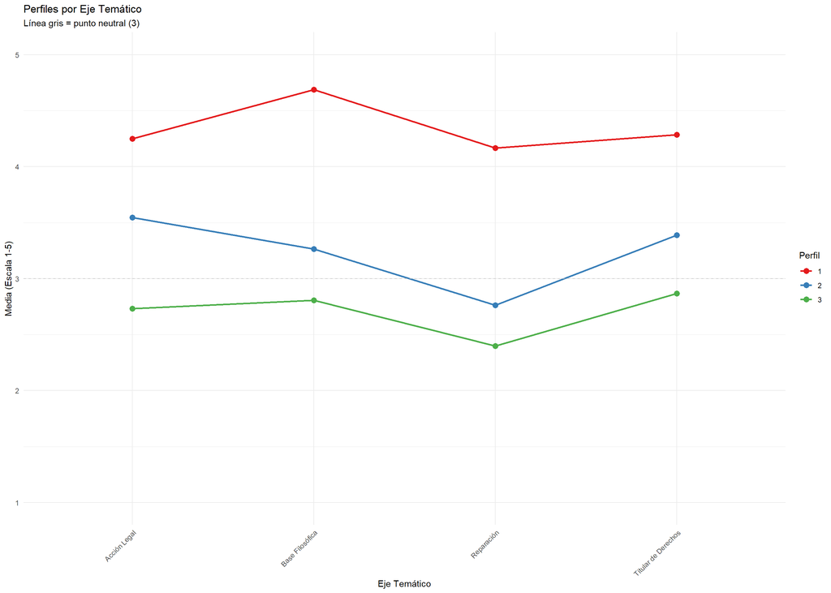

```r
# Separar ítems por eje temático
items_bf <- items_natureza[str_detect(items_natureza, "_bf_")]  # Base filosófica
items_al <- items_natureza[str_detect(items_natureza, "_al_")]  # Acción legal
items_td <- items_natureza[str_detect(items_natureza, "_td_")]  # Titular de derechos
items_rep <- items_natureza[str_detect(items_natureza, "_rep_")] # Reparación

# Calcular medias por eje y perfil
ejes_data <- get_data(final_lpa) %>%
  select(all_of(items_natureza), Class) %>%
  pivot_longer(cols = -Class, names_to = "Item", values_to = "Response") %>%
  mutate(Eje = case_when(
    str_detect(Item, "_bf_") ~ "Base Filosófica",
    str_detect(Item, "_al_") ~ "Acción Legal",
    str_detect(Item, "_td_") ~ "Titular de Derechos",
    str_detect(Item, "_rep_") ~ "Reparación",
    TRUE ~ "Otro"
  )) %>%
  group_by(Class, Eje) %>%
  summarise(Media = mean(Response, na.rm = TRUE), .groups = "drop")

# Gráfico por ejes
ejes_data %>%
  ggplot(aes(x = Eje, y = Media, color = factor(Class), group = Class)) +
  geom_line(size = 1) +
  geom_point(size = 3) +
  geom_hline(yintercept = 3, linetype = "dashed", color = "gray", alpha = 0.7) +
  labs(title = "Perfiles por Eje Temático",
       subtitle = "Línea gris = punto neutral (3)",
       x = "Eje Temático",
       y = "Media (Escala 1-5)",
       color = "Perfil") +
  theme_minimal() +
  theme(axis.text.x = element_text(angle = 45, hjust = 1)) +
  scale_color_brewer(type = "qual", palette = "Set1") +
  ylim(1, 5)
```

```r
# Tabla resumen por ejes
ejes_data %>%
  pivot_wider(names_from = Class,
              values_from = Media,
              names_prefix = "Perfil_") %>%
  kable(caption = "Medias por eje temático y perfil (Escala 1-5)",
        digits = 3)
```

Medias por eje temático y perfil (Escala 1-5)

| Eje | Perfil_1 | Perfil_2 | Perfil_3 |
| --- | --- | --- | --- |
| Acción Legal | 4.25 | 3.55 | 2.73 |
| Base Filosófica | 4.69 | 3.26 | 2.81 |
| Reparación | 4.17 | 2.76 | 2.40 |
| Titular de Derechos | 4.29 | 3.39 | 2.87 |

# Relación entre Perfiles y Variables Demográficas

```r
# Combinar datos de perfiles con variables demográficas
# Primero asegurémonos de que coincidan las filas
profile_assignments_data <- get_data(final_lpa)

cat("Dimensiones de datos de perfiles:", dim(profile_assignments_data), "\n")
```

```
## Dimensiones de datos de perfiles: 139 27
```

```r
cat("Dimensiones de data_completo:", dim(data_completo), "\n")
```

```
## Dimensiones de data_completo: 140 31
```

```r
# Verificar si las dimensiones coinciden
if(nrow(profile_assignments_data) == nrow(data_completo)) {
  # Si coinciden, combinar directamente
  profile_data <- profile_assignments_data %>%
    bind_cols(data_completo %>% select(-all_of(items_natureza))) %>%
    select(-starts_with("CPROB"))

} else {
  # Si no coinciden, crear un índice para hacer match
  cat("Las dimensiones no coinciden. Creando índice para hacer match...\n")

  # Usar solo las variables demográficas de los casos que quedaron en data_lpa_clean
  # Assuming we need to match based on row order
  n_valid <- min(nrow(profile_assignments_data), nrow(data_completo))

  profile_data <- profile_assignments_data[1:n_valid, ] %>%
    bind_cols(data_completo[1:n_valid, ] %>% select(-all_of(items_natureza))) %>%
    select(-starts_with("CPROB"))
}
```

```
## Las dimensiones no coinciden. Creando índice para hacer match...
```

```r
cat("Dimensiones finales de profile_data:", dim(profile_data), "\n\n")
```

```
## Dimensiones finales de profile_data: 139 34
```

```r
# Verificar que tengamos las variables demográficas necesarias
required_vars <- c("sex", "Condition", "career", "edad")
available_vars <- intersect(required_vars, names(profile_data))
cat("Variables demográficas disponibles:", paste(available_vars, collapse = ", "), "\n\n")
```

```
## Variables demográficas disponibles: sex, Condition, career, edad
```

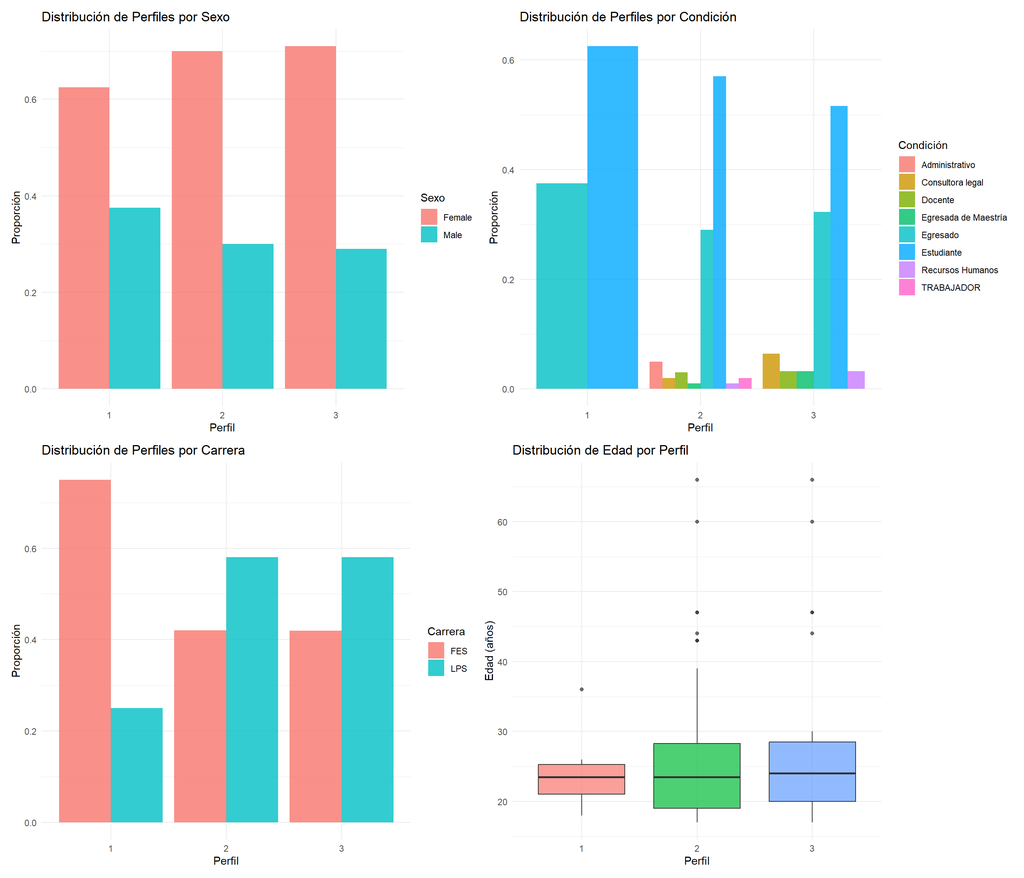

```r
# Solo crear gráficos para variables que existen
plots_list <- list()

# Análisis por sexo
if("sex" %in% names(profile_data)) {
  p1 <- profile_data %>%
    count(Class, sex) %>%
    group_by(Class) %>%
    mutate(prop = n / sum(n)) %>%
    ggplot(aes(x = factor(Class), y = prop, fill = sex)) +
    geom_col(position = "dodge", alpha = 0.8) +
    labs(title = "Distribución de Perfiles por Sexo",
         x = "Perfil", y = "Proporción", fill = "Sexo") +
    theme_minimal()
  plots_list[["sex"]] <- p1
}

# Análisis por condición
if("Condition" %in% names(profile_data)) {
  p2 <- profile_data %>%
    count(Class, Condition) %>%
    group_by(Class) %>%
    mutate(prop = n / sum(n)) %>%
    ggplot(aes(x = factor(Class), y = prop, fill = Condition)) +
    geom_col(position = "dodge", alpha = 0.8) +
    labs(title = "Distribución de Perfiles por Condición",
         x = "Perfil", y = "Proporción", fill = "Condición") +
    theme_minimal()
  plots_list[["condition"]] <- p2
}

# Análisis por carrera
if("career" %in% names(profile_data)) {
  p3 <- profile_data %>%
    count(Class, career) %>%
    group_by(Class) %>%
    mutate(prop = n / sum(n)) %>%
    ggplot(aes(x = factor(Class), y = prop, fill = career)) +
    geom_col(position = "dodge", alpha = 0.8) +
    labs(title = "Distribución de Perfiles por Carrera",
         x = "Perfil", y = "Proporción", fill = "Carrera") +
    theme_minimal()
  plots_list[["career"]] <- p3
}

# Análisis de edad por perfil
if("edad" %in% names(profile_data)) {
  p4 <- profile_data %>%
    ggplot(aes(x = factor(Class), y = edad, fill = factor(Class))) +
    geom_boxplot(alpha = 0.7) +
    labs(title = "Distribución de Edad por Perfil",
         x = "Perfil", y = "Edad (años)") +
    theme_minimal() +
    theme(legend.position = "none")
  plots_list[["edad"]] <- p4
}

# Mostrar gráficos disponibles
if(length(plots_list) >= 2) {
  if(length(plots_list) == 4) {
    (plots_list[[1]] + plots_list[[2]]) / (plots_list[[3]] + plots_list[[4]])
  } else if(length(plots_list) == 3) {
    plots_list[[1]] + plots_list[[2]] + plots_list[[3]]
  } else {
    plots_list[[1]] + plots_list[[2]]
  }
} else if(length(plots_list) == 1) {
  plots_list[[1]]
} else {
  cat("No hay suficientes variables demográficas para crear gráficos.\n")
}
```

```r
# Análisis estadístico de asociaciones
cat("\nPRUEBAS DE ASOCIACIÓN\n")
```

```
##
## PRUEBAS DE ASOCIACIÓN
```

```r
cat("=====================\n\n")
# Chi-cuadrado para variables categóricas (solo para variables disponibles)
vars_cat <- c("sex", "civilEst", "Condition", "career")

for(var in vars_cat) {
  if(var %in% names(profile_data)) {
    test_result <- chisq.test(table(profile_data$Class, profile_data[[var]]))
    cat("Chi-cuadrado -", var, ":\n")
    cat("X² =", round(test_result$statistic, 3),
        ", p =", round(test_result$p.value, 3), "\n\n")
  }
}
```

```
## Chi-cuadrado - sex :
## X² = 0.224 , p = 0.894
```

```
## Chi-cuadrado - civilEst :
## X² = 2.45 , p = 0.874
```

```
## Chi-cuadrado - Condition :
## X² = 7.14 , p = 0.929
```

```
## Chi-cuadrado - career :
## X² = 3.34 , p = 0.189
```

```r
# ANOVA para edad (solo si está disponible)
if("edad" %in% names(profile_data)) {
  edad_anova <- aov(edad ~ factor(Class), data = profile_data)
  cat("ANOVA - Edad por Perfil:\n")
  summary(edad_anova)
  cat("\n")
}
```

[output not shown]

```
## ANOVA - Edad por Perfil:
```

## Interpretación Narrativa para Publicación Científica

## Caracterización de los Perfiles Latentes

```r
# Calcular estadísticos clave para la interpretación narrativa
profile_means_summary <- get_estimates(final_lpa) %>%
  filter(Category == "Means") %>%
  select(Class, Parameter, Estimate) %>%
  pivot_wider(names_from = Class,
              values_from = Estimate,
              names_prefix = "Perfil_")

# Calcular medias generales por perfil y enfoque
narrative_data <- get_data(final_lpa) %>%
  select(all_of(items_natureza), Class) %>%
  pivot_longer(cols = -Class, names_to = "Item", values_to = "Response") %>%
  mutate(
    Enfoque = case_when(
      str_detect(Item, "_ant") ~ "Antropocéntrico",
      str_detect(Item, "_bio") ~ "Biocéntrico",
      TRUE ~ "Otro"
    ),
    Eje = case_when(
      str_detect(Item, "_bf_") ~ "Base Filosófica",
      str_detect(Item, "_al_") ~ "Acción Legal",
      str_detect(Item, "_td_") ~ "Titular de Derechos",
      str_detect(Item, "_rep_") ~ "Reparación",
      TRUE ~ "Otro"
    )
  ) %>%
  group_by(Class, Enfoque, Eje) %>%
  summarise(
    Media = mean(Response, na.rm = TRUE),
    DE = sd(Response, na.rm = TRUE),
    .groups = "drop"
  )

# Medias globales por enfoque y perfil
global_means <- narrative_data %>%
  group_by(Class, Enfoque) %>%
  summarise(Media_Global = mean(Media), .groups = "drop") %>%
  pivot_wider(names_from = Enfoque, values_from = Media_Global)

# Mostrar tabla resumen para interpretación
cat("MEDIAS GLOBALES POR PERFIL Y ENFOQUE (ESCALA 1-5):\n")
```

```
## MEDIAS GLOBALES POR PERFIL Y ENFOQUE (ESCALA 1-5):
```

```r
cat("==================================================\n")
kable(global_means, digits = 3, caption = "Medias globales por perfil y enfoque")
```

Medias globales por perfil y enfoque

| Class | Antropocéntrico | Biocéntrico |
| --- | --- | --- |
| 1 | 4.23 | 4.39 |
| 2 | 2.38 | 4.12 |
| 3 | 2.46 | 2.93 |

```r
# Clasificación de los participantes
class_distribution <- table(get_data(final_lpa)$Class)
class_percentages <- round(prop.table(class_distribution) * 100, 1)

cat("\nDISTRIBUCIÓN DE PARTICIPANTES POR PERFIL:\n")
```

```
##
## DISTRIBUCIÓN DE PARTICIPANTES POR PERFIL:
```

```r
cat("=========================================\n")
for(i in 1:length(class_distribution)) {
  cat("Perfil", i, ":", class_distribution[i], "participantes (",
      class_percentages[i], "%\n")
}
```

```
## Perfil 1 : 8 participantes ( 5.8 %
## Perfil 2 : 100 participantes ( 71.9 %
## Perfil 3 : 31 participantes ( 22.3 %
```

## Hallazgos Principales

Caracterización automática de los perfiles basada en los datos

[output not shown]

### Perfil 1: Pluralista (n = 8, 5.8%)

Este perfil presenta una orientación **mixta** hacia los derechos de la naturaleza (Media Antropocéntrica = 4.32, Media Biocéntrica = 4.5). Los participantes de este grupo representan el 5.8% de la muestra.

```
## **Caracterización por ejes temáticos:**
```

```
## - ** Acción Legal **: Media = 4.25 (intensidad alta )
## - ** Base Filosófica **: Media = 4.69 (intensidad alta )
## - ** Reparación **: Media = 4.17 (intensidad alta )
## - ** Titular de Derechos **: Media = 4.29 (intensidad alta )
```

### Perfil 2: Ecocéntrico Fuerte (n = 100, 71.9%)

Este perfil muestra una orientación **biocéntrica** (Media Antropocéntrica = 2.39, Media Biocéntrica = 4.08). Representa el 71.9% de la muestra.

```
## **Caracterización por ejes temáticos:**
```

```
## - ** Acción Legal **: Media = 3.55 (intensidad alta )
## - ** Base Filosófica **: Media = 3.26 (intensidad moderada )
## - ** Reparación **: Media = 2.76 (intensidad moderada )
## - ** Titular de Derechos **: Media = 3.39 (intensidad moderada )
```

### Perfil 3: Perfil Biocéntrica (n = 31, 22.3%)

```
## **Caracterización por ejes temáticos:**
```

```
## - ** Acción Legal **: Media = 2.73 (intensidad moderada )
## - ** Base Filosófica **: Media = 2.81 (intensidad moderada )
## - ** Reparación **: Media = 2.4 (intensidad baja )
## - ** Titular de Derechos **: Media = 2.87 (intensidad moderada )
```

# Análisis Detallado para Interpretación Narrativa

## Caracterización Específica por Perfil

```r
# Extraer medias por perfil para análisis detallado
profile_means_detailed <- get_estimates(final_lpa) %>%
  filter(Category == "Means") %>%
  select(Class, Parameter, Estimate) %>%
  arrange(Class, desc(Estimate))

cat("ANÁLISIS DETALLADO POR PERFIL\n")
```

```
## ANÁLISIS DETALLADO POR PERFIL
```

```r
cat("===============================\n\n")
# Función para clasificar intensidad de respuesta
classify_intensity <- function(score) {
  case_when(
    score >= 4.5 ~ "Muy alta",
    score >= 4.0 ~ "Alta",
    score >= 3.5 ~ "Moderadamente alta",
    score >= 3.0 ~ "Neutra/Moderada",
    score >= 2.5 ~ "Moderadamente baja",
    score >= 2.0 ~ "Baja",
    TRUE ~ "Muy baja"
  )
}

# Función para extraer eje temático
extract_axis <- function(item) {
  case_when(
    str_detect(item, "_bf_") ~ "Base Filosófica",
    str_detect(item, "_al_") ~ "Acción Legal",
    str_detect(item, "_td_") ~ "Titular de Derechos",
    str_detect(item, "_rep_") ~ "Reparación",
    TRUE ~ "Otro"
  )
}

# Función para extraer orientación
extract_orientation <- function(item) {
  case_when(
    str_detect(item, "_ant") ~ "Antropocéntrico",
    str_detect(item, "_bio") ~ "Biocéntrico",
    TRUE ~ "Otro"
  )
}

# Análisis por cada perfil
for(perfil in 1:3) {
  cat("### PERFIL", perfil, "###\n")
  cat("==================\n\n")

  # Filtrar datos del perfil actual
  datos_perfil <- profile_means_detailed %>%
    filter(Class == perfil) %>%
    mutate(
      Intensidad = classify_intensity(Estimate),
      Eje = extract_axis(Parameter),
      Orientacion = extract_orientation(Parameter)
    ) %>%
    arrange(desc(Estimate))

  # Ítems de mayor respuesta (distintivos altos)
  items_distintivos_altos <- datos_perfil %>% filter(Estimate >= 4.0)
  if(nrow(items_distintivos_altos) > 0) {
    cat("**ÍTEMS DISTINTIVOS ALTOS (≥ 4.0):**\n")
    for(i in 1:nrow(items_distintivos_altos)) {
      cat("- **", items_distintivos_altos$Parameter[i], "** (",
          items_distintivos_altos$Eje[i], " - ",
          items_distintivos_altos$Orientacion[i], "): ",
          items_distintivos_altos$Estimate[i], " (",
          items_distintivos_altos$Intensidad[i], ")\n")
    }
    cat("\n")
  }

  # Ítems moderadamente altos (3.5-3.99)
  items_moderados_altos <- datos_perfil %>% filter(Estimate >= 3.5 & Estimate < 4.0)
  if(nrow(items_moderados_altos) > 0) {
    cat("**ÍTEMS MODERADAMENTE ALTOS (3.5-3.99):**\n")
    for(i in 1:nrow(items_moderados_altos)) {
      cat("- **", items_moderados_altos$Parameter[i], "** (",
          items_moderados_altos$Eje[i], " - ",
          items_moderados_altos$Orientacion[i], "): ",
          items_moderados_altos$Estimate[i], "\n")
    }
    cat("\n")
  }

  # Ítems distintivos bajos (≤ 2.5)
  items_distintivos_bajos <- datos_perfil %>% filter(Estimate <= 2.5)
  if(nrow(items_distintivos_bajos) > 0) {
    cat("**ÍTEMS DISTINTIVOS BAJOS (≤ 2.5):**\n")
    for(i in 1:nrow(items_distintivos_bajos)) {
      cat("- **", items_distintivos_bajos$Parameter[i], "** (",
          items_distintivos_bajos$Eje[i], " - ",
          items_distintivos_bajos$Orientacion[i], "): ",
          items_distintivos_bajos$Estimate[i], " (",
          items_distintivos_bajos$Intensidad[i], ")\n")
    }
    cat("\n")
  }

  # Análisis por orientación
  resumen_orientacion <- datos_perfil %>%
    group_by(Orientacion) %>%
    summarise(
      N_items = n(),
      Media = round(mean(Estimate), 2),
      Min = round(min(Estimate), 2),
      Max = round(max(Estimate), 2),
      .groups = "drop"
    )

  cat("**RESUMEN POR ORIENTACIÓN:**\n")
  for(i in 1:nrow(resumen_orientacion)) {
    cat("- **", resumen_orientacion$Orientacion[i], "**: ",
        resumen_orientacion$N_items[i], " ítems, Media = ",
        resumen_orientacion$Media[i], " (rango: ",
        resumen_orientacion$Min[i], "-", resumen_orientacion$Max[i], ")\n")
  }

  # Análisis por eje temático
  resumen_ejes <- datos_perfil %>%
    group_by(Eje) %>%
    summarise(
      N_items = n(),
      Media = round(mean(Estimate), 2),
      Items_Altos = sum(Estimate >= 4.0),
      Items_Bajos = sum(Estimate <= 2.5),
      .groups = "drop"
    ) %>%
    arrange(desc(Media))

  cat("\n**RESUMEN POR EJE TEMÁTICO:**\n")
  for(i in 1:nrow(resumen_ejes)) {
    cat("- **", resumen_ejes$Eje[i], "**: Media = ",
        resumen_ejes$Media[i], " (", resumen_ejes$N_items[i],
        " ítems, ", resumen_ejes$Items_Altos[i],
        " altos, ", resumen_ejes$Items_Bajos[i], " bajos)\n")
  }

  cat("\n" , rep("-", 50), "\n\n")
}
```

```
## ### PERFIL 1 ###
## ==================
##
## **ÍTEMS DISTINTIVOS ALTOS (≥ 4.0):**
## - ** q4_td_bio ** ( Titular de Derechos  -  Biocéntrico ):  5  ( Muy alta )
## - ** q22_bf_ant ** ( Base Filosófica  -  Antropocéntrico ):  4.99  ( Muy alta )
## - ** q21_bf_bio ** ( Base Filosófica  -  Biocéntrico ):  4.75  ( Muy alta )
## - ** q10_bf_bio ** ( Base Filosófica  -  Biocéntrico ):  4.75  ( Muy alta )
## - ** q5_al_bio ** ( Acción Legal  -  Biocéntrico ):  4.75  ( Muy alta )
## - ** q18_rep_ant ** ( Reparación  -  Antropocéntrico ):  4.75  ( Muy alta )
## - ** q6_bf_bio ** ( Base Filosófica  -  Biocéntrico ):  4.74  ( Muy alta )
## - ** q19_td_bio ** ( Titular de Derechos  -  Biocéntrico ):  4.74  ( Muy alta )
## - ** q27_bf_ant ** ( Base Filosófica  -  Antropocéntrico ):  4.74  ( Muy alta )
## - ** q20_bf_ant ** ( Base Filosófica  -  Antropocéntrico ):  4.74  ( Muy alta )
## - ** q26_td_ant ** ( Titular de Derechos  -  Antropocéntrico ):  4.74  ( Muy alta )
## - ** q2_bf_ant ** ( Base Filosófica  -  Antropocéntrico ):  4.49  ( Alta )
## - ** q12_bf_bio ** ( Base Filosófica  -  Biocéntrico ):  4.25  ( Alta )
## - ** q11_td_bio ** ( Titular de Derechos  -  Biocéntrico ):  4.25  ( Alta )
## - ** q9_td_bio ** ( Titular de Derechos  -  Biocéntrico ):  4.25  ( Alta )
## - ** q13_al_bio ** ( Acción Legal  -  Biocéntrico ):  4  ( Alta )
## - ** q14_rep_bio ** ( Reparación  -  Biocéntrico ):  4  ( Alta )
##
## **ÍTEMS MODERADAMENTE ALTOS (3.5-3.99):**
## - ** q7_al_ant ** ( Acción Legal  -  Antropocéntrico ):  4
## - ** q24_td_ant ** ( Titular de Derechos  -  Antropocéntrico ):  3.75
## - ** q8_rep_ant ** ( Reparación  -  Antropocéntrico ):  3.75
##
## **RESUMEN POR ORIENTACIÓN:**
## - ** Antropocéntrico **:  10  ítems, Media =  4.32  (rango:  3.25 - 4.99 )
## - ** Biocéntrico **:  11  ítems, Media =  4.5  (rango:  4 - 5 )
##
## **RESUMEN POR EJE TEMÁTICO:**
## - ** Base Filosófica **: Media =  4.68  ( 8  ítems,  8  altos,  0  bajos)
## - ** Titular de Derechos **: Media =  4.28  ( 7  ítems,  5  altos,  0  bajos)
## - ** Acción Legal **: Media =  4.25  ( 3  ítems,  2  altos,  0  bajos)
## - ** Reparación **: Media =  4.17  ( 3  ítems,  2  altos,  0  bajos)
##
##  - - - - - - - - - - - - - - - - - - - - - - - - - - - - - - - - - - - - - - - - - - - - - - - - - -
##
## ### PERFIL 2 ###
```

[output cut: 43 more lines]

```
## - ** q7_al_ant ** ( Acción Legal  -  Antropocéntrico ):  2.32  ( Baja )
## - ** q18_rep_ant ** ( Reparación  -  Antropocéntrico ):  2.27  ( Baja )
## - ** q8_rep_ant ** ( Reparación  -  Antropocéntrico ):  2.06  ( Baja )
##
## **RESUMEN POR ORIENTACIÓN:**
## - ** Antropocéntrico **:  10  ítems, Media =  2.53  (rango:  2.06 - 2.97 )
## - ** Biocéntrico **:  11  ítems, Media =  2.96  (rango:  2.36 - 3.5 )
##
## **RESUMEN POR EJE TEMÁTICO:**
## - ** Titular de Derechos **: Media =  2.86  ( 7  ítems,  0  altos,  1  bajos)
## - ** Base Filosófica **: Media =  2.8  ( 8  ítems,  0  altos,  1  bajos)
## - ** Acción Legal **: Media =  2.73  ( 3  ítems,  0  altos,  1  bajos)
## - ** Reparación **: Media =  2.4  ( 3  ítems,  0  altos,  2  bajos)
##
##  - - - - - - - - - - - - - - - - - - - - - - - - - - - - - - - - - - - - - - - - - - - - - - - - - -
```

## Ítems Más Discriminativos Entre Perfiles

```r
# Análisis ANOVA detallado para identificar ítems más discriminativos
cat("ÍTEMS MÁS DISCRIMINATIVOS ENTRE PERFILES\n")
```

```
## ÍTEMS MÁS DISCRIMINATIVOS ENTRE PERFILES
```

```r
cat("=========================================\n\n")
lpa_data_with_class <- get_data(final_lpa)
anova_detailed <- data.frame()

for(item in items_natureza) {
  if(item %in% names(lpa_data_with_class)) {
    # ANOVA
    anova_test <- aov(lpa_data_with_class[[item]] ~ factor(lpa_data_with_class$Class))
    f_stat <- summary(anova_test)[[1]]$`F value`[1]
    p_value <- summary(anova_test)[[1]]$`Pr(>F)`[1]

    # Medias por perfil para este ítem
    medias_item <- lpa_data_with_class %>%
      group_by(Class) %>%
      summarise(Media = round(mean(.data[[item]], na.rm = TRUE), 2), .groups = "drop")

    # Calcular rango (diferencia max-min)
    rango <- max(medias_item$Media) - min(medias_item$Media)

    anova_detailed <- rbind(anova_detailed,
                           data.frame(
                             Item = item,
                             F_stat = round(f_stat, 2),
                             p_value = round(p_value, 4),
                             Rango = round(rango, 2),
                             Perfil1 = medias_item$Media[medias_item$Class == 1],
                             Perfil2 = medias_item$Media[medias_item$Class == 2],
                             Perfil3 = medias_item$Media[medias_item$Class == 3],
                             Eje = extract_axis(item),
                             Orientacion = extract_orientation(item)
                           ))
  }
}

# Ordenar por F estadístico (más discriminativo primero)
anova_detailed <- anova_detailed %>% arrange(desc(F_stat))

cat("**TOP 15 ÍTEMS MÁS DISCRIMINATIVOS:**\n\n")
```

```
## **TOP 15 ÍTEMS MÁS DISCRIMINATIVOS:**
```

```r
for(i in 1:min(15, nrow(anova_detailed))) {
  cat("**", i, ". ", anova_detailed$Item[i], "**\n")
  cat("   - Eje:", anova_detailed$Eje[i], " | Orientación:", anova_detailed$Orientacion[i], "\n")
  cat("   - F =", anova_detailed$F_stat[i], ", p =", anova_detailed$p_value[i],
      " | Rango =", anova_detailed$Rango[i], "\n")
  cat("   - Medias por perfil: P1 =", anova_detailed$Perfil1[i],
      ", P2 =", anova_detailed$Perfil2[i], ", P3 =", anova_detailed$Perfil3[i], "\n\n")
}
```

```
## ** 1 .  q14_rep_bio **
##    - Eje: Reparación  | Orientación: Biocéntrico
##    - F = 92.7 , p = 0  | Rango = 1.47
##    - Medias por perfil: P1 = 4 , P2 = 4.31 , P3 = 2.84
##
## ** 2 .  q10_bf_bio **
##    - Eje: Base Filosófica  | Orientación: Biocéntrico
##    - F = 61.5 , p = 0  | Rango = 2.43
##    - Medias por perfil: P1 = 4.75 , P2 = 3.87 , P3 = 2.32
##
## ** 3 .  q18_rep_ant **
##    - Eje: Reparación  | Orientación: Antropocéntrico
##    - F = 52.9 , p = 0  | Rango = 2.65
##    - Medias por perfil: P1 = 4.75 , P2 = 2.1 , P3 = 2.29
##
## ** 4 .  q4_td_bio **
##    - Eje: Titular de Derechos  | Orientación: Biocéntrico
##    - F = 35.3 , p = 0  | Rango = 2.29
##    - Medias por perfil: P1 = 5 , P2 = 4.15 , P3 = 2.71
##
## ** 5 .  q11_td_bio **
##    - Eje: Titular de Derechos  | Orientación: Biocéntrico
##    - F = 31 , p = 0  | Rango = 1.12
##    - Medias por perfil: P1 = 4.25 , P2 = 4.24 , P3 = 3.13
##
## ** 6 .  q2_bf_ant **
##    - Eje: Base Filosófica  | Orientación: Antropocéntrico
##    - F = 29 , p = 0  | Rango = 2.35
##    - Medias por perfil: P1 = 4.5 , P2 = 2.15 , P3 = 2.84
##
## ** 7 .  q13_al_bio **
##    - Eje: Acción Legal  | Orientación: Biocéntrico
##    - F = 27.5 , p = 0  | Rango = 1.24
##    - Medias por perfil: P1 = 4 , P2 = 4.05 , P3 = 2.81
##
## ** 8 .  q26_td_ant **
##    - Eje: Titular de Derechos  | Orientación: Antropocéntrico
##    - F = 26.7 , p = 0  | Rango = 2.45
##    - Medias por perfil: P1 = 4.75 , P2 = 2.3 , P3 = 2.39
##
```

[output cut: 19 more lines]

```
##
## ** 13 .  q12_bf_bio **
##    - Eje: Base Filosófica  | Orientación: Biocéntrico
##    - F = 19.9 , p = 0  | Rango = 1.16
##    - Medias por perfil: P1 = 4.25 , P2 = 4.26 , P3 = 3.1
##
## ** 14 .  q27_bf_ant **
##    - Eje: Base Filosófica  | Orientación: Antropocéntrico
##    - F = 14.9 , p = 0  | Rango = 2.1
##    - Medias por perfil: P1 = 4.75 , P2 = 2.8 , P3 = 2.65
##
## ** 15 .  q8_rep_ant **
##    - Eje: Reparación  | Orientación: Antropocéntrico
##    - F = 13.8 , p = 0  | Rango = 1.87
##    - Medias por perfil: P1 = 3.75 , P2 = 1.88 , P3 = 2.06
```

```r
# Tabla resumen de los más discriminativos
top_discriminative_detailed <- anova_detailed %>%
  head(10) %>%
  select(Item, F_stat, p_value, Rango, Perfil1, Perfil2, Perfil3, Eje, Orientacion)

kable(top_discriminative_detailed,
      caption = "Top 10 ítems más discriminativos con medias por perfil",
      digits = c(0, 2, 4, 2, 2, 2, 2, 0, 0))
```

Top 10 ítems más discriminativos con medias por perfil

| Item | F_stat | p_value | Rango | Perfil1 | Perfil2 | Perfil3 | Eje | Orientacion |
| --- | --- | --- | --- | --- | --- | --- | --- | --- |
| q14_rep_bio | 92.7 | 0 | 1.47 | 4.00 | 4.31 | 2.84 | Reparación | Biocéntrico |
| q10_bf_bio | 61.5 | 0 | 2.43 | 4.75 | 3.87 | 2.32 | Base Filosófica | Biocéntrico |
| q18_rep_ant | 52.9 | 0 | 2.65 | 4.75 | 2.10 | 2.29 | Reparación | Antropocéntrico |
| q4_td_bio | 35.3 | 0 | 2.29 | 5.00 | 4.15 | 2.71 | Titular de Derechos | Biocéntrico |
| q11_td_bio | 31.0 | 0 | 1.12 | 4.25 | 4.24 | 3.13 | Titular de Derechos | Biocéntrico |
| q2_bf_ant | 29.0 | 0 | 2.35 | 4.50 | 2.15 | 2.84 | Base Filosófica | Antropocéntrico |
| q13_al_bio | 27.5 | 0 | 1.24 | 4.00 | 4.05 | 2.81 | Acción Legal | Biocéntrico |
| q26_td_ant | 26.7 | 0 | 2.45 | 4.75 | 2.30 | 2.39 | Titular de Derechos | Antropocéntrico |
| q6_bf_bio | 25.7 | 0 | 1.98 | 4.75 | 3.94 | 2.77 | Base Filosófica | Biocéntrico |
| q22_bf_ant | 24.9 | 0 | 2.55 | 5.00 | 2.45 | 2.68 | Base Filosófica | Antropocéntrico |

## Interpretación Basada en Patrones Emergentes

```r
cat("PATRONES DISTINTIVOS POR PERFIL\n")
```

```
## PATRONES DISTINTIVOS POR PERFIL
```

```r
cat("================================\n\n")
# Análizar patrones únicos de cada perfil
for(perfil in 1:3) {
  cat("### PERFIL", perfil, "- PATRONES DISTINTIVOS ###\n")

  # Obtener ítems donde este perfil tiene la media más alta
  items_max_perfil <- anova_detailed %>%
    rowwise() %>%
    mutate(Max_Perfil = which.max(c(Perfil1, Perfil2, Perfil3))) %>%
    filter(Max_Perfil == perfil & F_stat >= 5) %>% # Solo ítems significativamente discriminativos
    arrange(desc(F_stat))

  if(nrow(items_max_perfil) > 0) {
    cat("**Ítems donde este perfil destaca MÁS:**\n")
    for(i in 1:min(8, nrow(items_max_perfil))) {
      media_perfil <- items_max_perfil[i, paste0("Perfil", perfil)][[1]]
      cat("- ", items_max_perfil$Item[i], " (", items_max_perfil$Eje[i],
          " - ", items_max_perfil$Orientacion[i], "): ",
          media_perfil, "\n")
    }
  }

  # Obtener ítems donde este perfil tiene la media más baja
  items_min_perfil <- anova_detailed %>%
    rowwise() %>%
    mutate(Min_Perfil = which.min(c(Perfil1, Perfil2, Perfil3))) %>%
    filter(Min_Perfil == perfil & F_stat >= 5) %>%
    arrange(desc(F_stat))

  if(nrow(items_min_perfil) > 0) {
    cat("\n**Ítems donde este perfil destaca MENOS:**\n")
    for(i in 1:min(5, nrow(items_min_perfil))) {
      media_perfil <- items_min_perfil[i, paste0("Perfil", perfil)][[1]]
      cat("- ", items_min_perfil$Item[i], " (", items_min_perfil$Eje[i],
          " - ", items_min_perfil$Orientacion[i], "): ",
          media_perfil, "\n")
    }
  }

  cat("\n", rep("-", 60), "\n\n")
}
```

```
## ### PERFIL 1 - PATRONES DISTINTIVOS ###
## **Ítems donde este perfil destaca MÁS:**
## -  q10_bf_bio  ( Base Filosófica  -  Biocéntrico ):  4.75
## -  q18_rep_ant  ( Reparación  -  Antropocéntrico ):  4.75
## -  q4_td_bio  ( Titular de Derechos  -  Biocéntrico ):  5
## -  q11_td_bio  ( Titular de Derechos  -  Biocéntrico ):  4.25
## -  q2_bf_ant  ( Base Filosófica  -  Antropocéntrico ):  4.5
## -  q26_td_ant  ( Titular de Derechos  -  Antropocéntrico ):  4.75
## -  q6_bf_bio  ( Base Filosófica  -  Biocéntrico ):  4.75
## -  q22_bf_ant  ( Base Filosófica  -  Antropocéntrico ):  5
##
##  - - - - - - - - - - - - - - - - - - - - - - - - - - - - - - - - - - - - - - - - - - - - - - - - - - - - - - - - - - - -
##
## ### PERFIL 2 - PATRONES DISTINTIVOS ###
## **Ítems donde este perfil destaca MÁS:**
## -  q14_rep_bio  ( Reparación  -  Biocéntrico ):  4.31
## -  q13_al_bio  ( Acción Legal  -  Biocéntrico ):  4.05
## -  q12_bf_bio  ( Base Filosófica  -  Biocéntrico ):  4.26
##
## **Ítems donde este perfil destaca MENOS:**
## -  q18_rep_ant  ( Reparación  -  Antropocéntrico ):  2.1
## -  q2_bf_ant  ( Base Filosófica  -  Antropocéntrico ):  2.15
## -  q26_td_ant  ( Titular de Derechos  -  Antropocéntrico ):  2.3
## -  q22_bf_ant  ( Base Filosófica  -  Antropocéntrico ):  2.45
## -  q8_rep_ant  ( Reparación  -  Antropocéntrico ):  1.88
##
##  - - - - - - - - - - - - - - - - - - - - - - - - - - - - - - - - - - - - - - - - - - - - - - - - - - - - - - - - - - - -
##
## ### PERFIL 3 - PATRONES DISTINTIVOS ###
##
## **Ítems donde este perfil destaca MENOS:**
## -  q14_rep_bio  ( Reparación  -  Biocéntrico ):  2.84
## -  q10_bf_bio  ( Base Filosófica  -  Biocéntrico ):  2.32
## -  q4_td_bio  ( Titular de Derechos  -  Biocéntrico ):  2.71
## -  q11_td_bio  ( Titular de Derechos  -  Biocéntrico ):  3.13
## -  q13_al_bio  ( Acción Legal  -  Biocéntrico ):  2.81
##
##  - - - - - - - - - - - - - - - - - - - - - - - - - - - - - - - - - - - - - - - - - - - - - - - - - - - - - - - - - - - -
```

```r
cat("SÍNTESIS INTERPRETATIVA\n")
```

```
## SÍNTESIS INTERPRETATIVA
```

```r
cat("=======================\n")
cat("Utiliza la información anterior para describir narrativamente cada perfil:\n\n")
```

```
## Utiliza la información anterior para describir narrativamente cada perfil:
```

```r
cat("1. **Identifica los ítems distintivos altos** de cada perfil (≥4.0)\n")
```

```
## 1. **Identifica los ítems distintivos altos** de cada perfil (≥4.0)
```

```r
cat("2. **Observa los ítems distintivos bajos** (≤2.5)\n")
```

```
## 2. **Observa los ítems distintivos bajos** (≤2.5)
```

```r
cat("3. **Analiza los patrones por eje temático** (dónde destaca cada perfil)\n")
```

```
## 3. **Analiza los patrones por eje temático** (dónde destaca cada perfil)
```

```r
cat("4. **Considera la orientación predominante** (antropocéntrica vs. biocéntrica)\n")
```

```
## 4. **Considera la orientación predominante** (antropocéntrica vs. biocéntrica)
```

```r
cat("5. **Revisa los ítems más discriminativos** para entender diferencias clave\n\n")
```

```
## 5. **Revisa los ítems más discriminativos** para entender diferencias clave
```

```r
cat("Con esta información puedes crear descripciones narrativas específicas\n")
```

```
## Con esta información puedes crear descripciones narrativas específicas
```

```r
cat("basadas en los datos empíricos de tu análisis.\n")
```

```
## basadas en los datos empíricos de tu análisis.
```

## Diferencias Entre Perfiles

```r
# Análisis de diferencias significativas entre perfiles
# ANOVA para cada ítem
anova_results <- data.frame()
lpa_data_with_class <- get_data(final_lpa)

for(item in items_natureza) {
  if(item %in% names(lpa_data_with_class)) {
    anova_test <- aov(lpa_data_with_class[[item]] ~ factor(lpa_data_with_class$Class))
    f_stat <- summary(anova_test)[[1]]$`F value`[1]
    p_value <- summary(anova_test)[[1]]$`Pr(>F)`[1]

    anova_results <- rbind(anova_results,
                          data.frame(
                            Item = item,
                            F_statistic = f_stat,
                            p_value = p_value,
                            Significant = ifelse(p_value < 0.05, "Sí", "No")
                          ))
  }
}

# Mostrar ítems más discriminativos
anova_results %>%
  arrange(desc(F_statistic)) %>%
  head(10) %>%
  kable(digits = 4, caption = "Los 10 ítems más discriminativos entre perfiles (Mayor F)")
```

Los 10 ítems más discriminativos entre perfiles (Mayor F)

| Item | F_statistic | p_value | Significant |
| --- | --- | --- | --- |
| q14_rep_bio | 92.7 | 0 | Sí |
| q10_bf_bio | 61.5 | 0 | Sí |
| q18_rep_ant | 52.9 | 0 | Sí |
| q4_td_bio | 35.3 | 0 | Sí |
| q11_td_bio | 31.0 | 0 | Sí |
| q2_bf_ant | 29.0 | 0 | Sí |
| q13_al_bio | 27.5 | 0 | Sí |
| q26_td_ant | 26.7 | 0 | Sí |
| q6_bf_bio | 25.7 | 0 | Sí |
| q22_bf_ant | 24.9 | 0 | Sí |

```r
# Calcular efecto de tamaño (eta cuadrado)
cat("\nÍTEMS CON MAYOR CAPACIDAD DISCRIMINATIVA:\n")
```

```
##
## ÍTEMS CON MAYOR CAPACIDAD DISCRIMINATIVA:
```

```r
cat("========================================\n")
top_items <- anova_results %>% arrange(desc(F_statistic)) %>% head(5)
for(i in 1:nrow(top_items)) {
  cat(i, ".", top_items$Item[i], " (F =", round(top_items$F_statistic[i], 2), ", p =", round(top_items$p_value[i], 4), ")\n")
}
```

```
## 1 . q14_rep_bio  (F = 92.7 , p = 0 )
## 2 . q10_bf_bio  (F = 61.5 , p = 0 )
## 3 . q18_rep_ant  (F = 52.9 , p = 0 )
## 4 . q4_td_bio  (F = 35.3 , p = 0 )
## 5 . q11_td_bio  (F = 31 , p = 0 )
```

## Implicaciones Conceptuales

Los hallazgos revelan una **heterogeneidad significativa** en las concepciones estudiantiles sobre los derechos de la naturaleza, lo cual tiene importantes implicaciones teóricas y prácticas:

### Pluralismo Conceptual

La emergencia de tres perfiles diferenciados evidencia que las actitudes hacia los derechos de la naturaleza no constituyen un constructo unidimensional, sino que reflejan **orientaciones complejas y multifacéticas**. Esta diversidad conceptual sugiere la necesidad de aproximaciones pedagógicas y políticas diferenciadas que reconozcan la pluralidad de marcos interpretativos.

### Tensión Antropocentrismo-Biocentrismo

```
## **Análisis de la tensión antropocentrismo-biocentrismo por perfil:**
```

```
## - **Perfil 1 **: Equilibrio conceptual (Δ = 0.17 )
## - **Perfil 2 **: Preferencia biocéntrica (Δ = 1.7 )
## - **Perfil 3 **: Preferencia biocéntrica (Δ = 0.41 )
```

Los perfiles identificados ilustran diferentes formas de **negociar la tensión clásica** entre perspectivas antropocéntricas y biocéntricas en el ámbito jurídico-ambiental. El análisis revela que los participantes adoptan estrategias diferenciadas para abordar esta dicotomía fundamental, desde el equilibrio conceptual hasta preferencias marcadas hacia uno u otro enfoque.

### Dimensiones Diferenciadas

El análisis por ejes temáticos revela que los participantes no necesariamente mantienen **consistencia absoluta** entre diferentes dimensiones de los derechos de la naturaleza. Algunos perfiles pueden mostrar orientaciones biocentristas en aspectos filosóficos pero antropocentristas en mecanismos legales, sugiriendo la **complejidad inherente** del tema.

## Implicaciones para la Formación Jurídica

### Diversidad de Enfoques Pedagógicos

La identificación de perfiles distintivos sugiere la necesidad de **estrategias pedagógicas diferenciadas** en la formación jurídica ambiental. Los estudiantes con diferentes orientaciones conceptuales pueden beneficiarse de aproximaciones metodológicas específicas que reconozcan sus marcos interpretativos previos.

### Desarrollo Curricular

Los hallazgos informan el **diseño curricular** de programas de derecho ambiental, sugiriendo la importancia de abordar explícitamente la diversidad de perspectivas y promover el diálogo crítico entre diferentes orientaciones conceptuales.

## Limitaciones del Estudio

El presente análisis presenta varias limitaciones que deben considerarse en la interpretación de los hallazgos:

## Futuras Líneas de Investigación

Los hallazgos abren varias líneas de investigación futuras:

1. **Validación longitudinal**: Examinar la estabilidad temporal de los perfiles identificados
2. **Estudios comparativos**: Replicar el análisis en diferentes contextos culturales y educativos
3. **Factores predictivos**: Investigar variables sociodemográficas, psicológicas y educativas asociadas a cada perfil
4. **Intervenciones educativas**: Diseñar y evaluar intervenciones pedagógicas basadas en los perfiles identificados
5. **Métodos mixtos**: Complementar los hallazgos cuantitativos con aproximaciones cualitativas para profundizar en la comprensión de cada perfil

# Conclusiones y Discusión

## Resumen de Hallazgos

```r
cat("RESUMEN DEL ANÁLISIS DE PERFILES LATENTES\n")
```

```
## RESUMEN DEL ANÁLISIS DE PERFILES LATENTES
```

```r
cat("==========================================\n\n")
cat("CARACTERÍSTICAS DE LA MUESTRA:\n")
```

```
## CARACTERÍSTICAS DE LA MUESTRA:
```

```r
cat("- Tamaño muestral total:", nrow(bd), "casos\n")
```

```
## - Tamaño muestral total: 143 casos
```

```r
cat("- Casos válidos para LPA:", nrow(data_lpa_clean), "casos\n")
```

```
## - Casos válidos para LPA: 139 casos
```

```r
cat("- Escala utilizada: 1-5 (Totalmente en desacuerdo - Totalmente de acuerdo)\n")
```

```
## - Escala utilizada: 1-5 (Totalmente en desacuerdo - Totalmente de acuerdo)
```

```r
cat("- Ítems analizados:", length(items_natureza), "(", length(items_ant), "antropocéntricos +", length(items_bio), "biocéntricos)\n\n")
```

```
## - Ítems analizados: 21 ( 10 antropocéntricos + 11 biocéntricos)
```

```r
cat("MODELO SELECCIONADO:\n")
```

```
## MODELO SELECCIONADO:
```

```r
cat("- Número de perfiles identificados:", n_profiles, "(establecido teóricamente)\n")
```

```
## - Número de perfiles identificados: 3 (establecido teóricamente)
```

```r
cat("- Criterios de ajuste del modelo final:\n")
```

```
## - Criterios de ajuste del modelo final:
```

```r
final_fit <- get_fit(final_lpa)

# Verificar si los criterios están disponibles
if(is.list(final_fit) && "AIC" %in% names(final_fit)) {
  cat("  * AIC:", round(final_fit$AIC, 2), "\n")
  cat("  * BIC:", round(final_fit$BIC, 2), "\n")
  cat("  * Entropía:", round(final_fit$Entropy, 3), "\n")

  if(final_fit$Entropy >= 0.8) {
    cat("  → Excelente clasificación (Entropía ≥ 0.8)\n")
  } else if(final_fit$Entropy >= 0.7) {
    cat("  → Buena clasificación (Entropía ≥ 0.7)\n")
  } else {
    cat("  → Clasificación aceptable (Entropía < 0.7)\n")
  }
} else {
  cat("  * Criterios de ajuste no disponibles\n")
}
```

```
##   * AIC: 7816
##   * BIC: 8068
##   * Entropía: 0.973
##   → Excelente clasificación (Entropía ≥ 0.8)
```

```r
cat("\nDISTRIBUCIÓN DE CASOS POR PERFIL:\n")
```

```
##
## DISTRIBUCIÓN DE CASOS POR PERFIL:
```

```r
class_dist <- table(get_data(final_lpa)$Class)
for(i in 1:length(class_dist)) {
  cat("- Perfil", i, ":", class_dist[i], "casos (",
      round(class_dist[i]/sum(class_dist)*100, 1), "%)\n")
}
```

```
## - Perfil 1 : 8 casos ( 5.8 %)
## - Perfil 2 : 100 casos ( 71.9 %)
## - Perfil 3 : 31 casos ( 22.3 %)
```

```r
cat("\nVARIABLES DEMOGRÁFICAS DISPONIBLES:\n")
```

```
##
## VARIABLES DEMOGRÁFICAS DISPONIBLES:
```

```r
cat("- Edad (continua)\n")
```

```
## - Edad (continua)
```

```r
cat("- Sexo:", paste(unique(bd$sex), collapse = ", "), "\n")
```

```
## - Sexo: Female, Male
```

```r
cat("- Condición:", paste(unique(bd$Condition), collapse = ", "), "\n")
```

```
## - Condición: Estudiante, Egresado, Recursos Humanos, TRABAJADOR, Consultora legal, Administrativo, Egresada de Maestría, Docente
```

```r
cat("- Carreras:", paste(unique(bd$career), collapse = ", "), "\n")
```

```
## - Carreras: FES, LPS
```

```r
cat("- Estados civiles:", length(unique(bd$civilEst)), "categorías\n")
```

```
## - Estados civiles: 4 categorías
```

```r
cat("- Departamentos:", length(unique(bd$dep)), "departamentos\n")
```

```
## - Departamentos: 18 departamentos
```

## Limitaciones y Futuras Direcciones

- **Tamaño muestral**: Con 143 casos y 21 variables, el ratio casos/variables (~6.8) está en el límite recomendado para LPA
- **Validación**: Los resultados deben validarse con muestras independientes
- **Estabilidad temporal**: Sería útil evaluar la estabilidad de los perfiles en el tiempo
- **Variables adicionales**: Considerar la inclusión de otras covariables relevantes

**Nota**: Este análisis proporciona una aproximación inicial a los perfiles latentes de actitudes hacia los derechos de la naturaleza. Los resultados deben interpretarse considerando el contexto teórico específico y las limitaciones metodológicas mencionadas.